# James Bond Gambling Strategy

Stephen Mullaly  
ISYE 6644  
Fall 2020

#### Abstract

James Bond, 007, is a secret agent for the British Secret Service.

In his many adventures in novels and film, James Bond often finds himself at a casino table.

While sipping martinis (shaken, not stirred of course) James Bond has become an accomplished gambler playing Roulette, Black Jack, Craps, Poker, and Bacarat.

The goal of this project is to look at the strategies that have been described in the books or films as best as they can be ascertained for Roulette and Black Jack. Does James Bond know how to beat the house or is he just as likely to lose as the rest of us? And for fun we will also look at the Black Jack strategy of another 'International Man of Mystery' to see how he would do compared to Mr. Bond.

It seems fitting to apply some Monte Carlo simulations to these games and, as a result, we see that the old adage, 'the house always wins', is true.

#### Problem Description

When it comes to gambling, everyone seems to have their own system that will allow them to beat the house and James Bond is no different.

In this project we will first look at Bond’s strategy regarding Roulette. In Roulette, Bond plays a combination of bets where he will win on 25 of the possible 37 results on a European Roulette wheel. In the event one of the 12 numbers that Bond did not bet on comes up he loses and will then double his bet for the next round. Consecutive losses result in consecutive doubling of the bet until the table maximum is reached. In the Roulette section of this report, Bond’s strategy will be implemented and tested to see if he can beat the house.

Next we will look at Bond’s Black Jack strategy. In this case, Bond does not have his own unique strategy but follows commonly accepted strategies regarding when to hit and stay, double his bet, or split his cards depending on what he has and what the dealer is showing (the dealer always keeps one card face down until all players have reached their final hand in turn). We will test Bond’s strategy playing five hands simultaneously like he does in the movie *License To Kill.*

After looking at Bond’s Black Jack strategy we will look at how another British spy, Austin Powers, would do playing Black Jack with his unique strategy. Austin never requests an additional card (hits) even when it would be to his advantage. This strategy relies on either being dealt a good initial hand or on the dealer busting (exceeding 21). We will test this strategy and see how it compares to Bond’s.

Finally, we will look at the performance in all three scenarios and see where are the biggest potential for gains and losses and where Bond should spend his time in the casino.

### Roulette

#### Roulette Strategy

In the book *Casino Royale*, James Bond plays Roulette with a very specific strategy that wagers \$200 per round.

The betting system is \$140 on high numbers (19-36), \$50 on six numbers 13-18, and \$10 on zero as an insurance.

If the ball lands on numbers 19 to 36, Bond will have a profit of \$80. If the ball lands on one of the 6 numbers from 13 to 18, Bond will have a profit of \$100. If the ball lands on zero, Bond will have \$160 profit. If the ball lands on a number from 1 to 12 Bond will lose.

Bond's strategy will be implemented over the course of 200 rounds of Roulette to see how he performs.

#### Roulette Code Development

For Roulette, the code is very straight forward.

A *for loop* is used to handle simulation replications with each pass through the *for loop* representing a new simulation run.

In each simulation replicant, a *while loop* is used to control the number of rounds of play. If the game reaches the maximum number of rounds or the player does not have enough money to cover the next round's bet, then that simulation run will end and a new run will begin.

The parameters at the top of the code can be used to adjust the simulation. *n_sim* is used to set the number of replicants run. *n_hands* will adjust the maximum number of rounds to play during each simulation replicant, and *bet* can be used to adjust the amount bet for each round of play.

Within the *for loop*, the variable *bank* is used to set the starting amount of money for the player in each simulation. Changing this will adjust each player's starting amount of money.

After running the simulation code there are several lines of output. This code will display the maximum value achieved out of all replicants, the average of the maximum value achieved in each replicant, and the average round where the maximum value occurred. The output code also shows the average balance after the final round of play across all replicants, the average amount of money lost on each round, and the average percent lost on each bet.

Two graphs are also created which show how the bank value varied as rounds were played for a number of simulation runs, and one shows the average value after every round across all simulation runs.

Results are shown below with the full code located in Appendix A.

```
Maximum Value Achieved:
20380.0
Average Maximum Value Achieved:
12043.39
Average Round Where Maximum is Achieved:
102.18
Average Final Value:
7099.39
Average lost or gained per round:
-14.5
Percentage of bet lost or gained per round:
-7.25
```

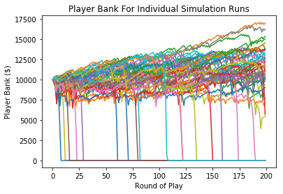

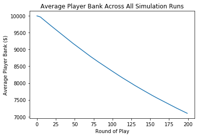

```python
#print some basic results
print('Maximum Value Achieved:')
print(max(max_bank_list))
print('Average Maximum Value Achieved:')
print(round(average_max,2))
print('Average Round Where Maximum is Achieved:')
print(round(average_round,2))
print('Average Final Value:')
print(round(average_bank[-1],2))

#determine loss or gain per hand
delta = average_bank[-1] - average_bank[0]
per_hand_loss = delta/n_hands
percent_loss = per_hand_loss/bet * 100

#print loss or gain results
print('Average lost or gained per round:')
print(round(per_hand_loss,2))
print('Percentage of bet lost or gained per round:')
print(round(percent_loss,2))

#plot a number of individual simulation results
plt.figure(1)
for i in range(0,600000,10000):
    plt.plot(results[i,0:200])

# Add title and axis names
plt.title('Player Bank For Individual Simulation Runs')
plt.xlabel('Round of Play')
plt.ylabel('Player Bank ($)')

#plot average player bank after every hand
plt.figure(2)
plt.plot(average_bank[0:200])

# Add title and axis names
plt.title('Average Player Bank Across All Simulation Runs')
plt.xlabel('Round of Play')
plt.ylabel('Average Player Bank ($)')
```

James Bond's system can result in winning over the course of 200 rounds of Roulette, but it also shows that, on average, the house always wins, even against James Bond.

### Black Jack

#### James Bond Black Jack Strategy

While James Bond doesn't show his entire Black Jack strategy, we see him play in the movie *License to Kill* and he doubles down on an 11 and splits 8s. Based on this play, and the fact that James Bond knows everything from Faberge Eggs to lepidoptery, we will assume that Bond knows the best way to handle any combination he is dealt. We will define his strategy using the following table:

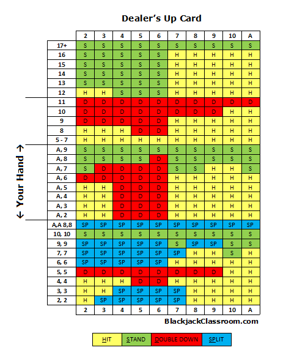

https://www.youtube.com/watch?v=ccBqiW3rR70

#### Black Jack Code Development

For Black Jack, the code is much more demanding than for Roulette.

Similar to Roulette, a *for loop* is used to handle simulation replications with each pass through the *for loop* representing a new simulation run.

In each simulation run, a *while loop* is used to control the number of rounds of play. If the game reaches the maximum number of rounds or the player does not have enough money to cover the next round's bet then the simulation run will end.

For each round of play in the simulation, cards are dealt in order to each player hand and then the dealer hand in two cycles. This mimics the actual order of play in a casino. This also allows for accurate re-creation of playing multiple hands at once instead of simply increasing the number of hands played. In a casino setting, the dealer would have one hand that the player would be going against five times.

After the cards are dealt there is logic in place that will handle how the player should respond. The options to respond are to hit (request another card), stand (keep your cards as they are), double down (double the amount of your bet), and split (take the two cards dealt and use each of them to create two new hands). The dealer in Black Jack only shows one card so the logic is based on the player's hand and dealer's card that is shown. Once all player hands go through the logic and arrive at their final value then there is logic for how the dealer should play. The dealer will hit until their total is 17 or greater, and will also hit if they have a 17 but one of the cards is an Ace with a value of 11.

Once the dealer has a final hand then it can be determined who is the winner and how bets should be paid out.

The parameters at the top of the code can be used to adjust the simulation. *n_sim* is used to set the number of replicants run. *n_rounds* changes how many rounds of play are in each simulation run and *n_hands* changes how many hands to play simultaneously in each round of play. The variable *n_decks* is the number of decks that cards can be drawn from and *shuffle_perc* is the percentage of cards to be used from the deck before they are replaced with newly shuffled decks. *bet* can be used to adjust the amount bet for each hand of play.

Within the for loop the variable *bank* is used to set the starting amount of money for the player in each simulation. Changing this will adjust the amount of money the player starts with.

After running the code the next cell is used for output. It will display the maximum value achieved out of all replicants, the average of the maximum value achieved in all replicants, and the average round where the maximum value occurred.

After running the simulation code there are several lines of output. This code will display the maximum value achieved out of all replicants, the average of the maximum value achieved in each replicant, and the average round where the maximum value occurred. The output code also shows the average balance after the final round of play across all replicants, the average amount of money lost on each round, and the average percent lost on each bet.

Results are shown below with the full code located in Appendix B.

```
Maximum Value Achieved:
1110000
Average Maximum Value Achieved:
387781.37
Average Round Where Maximum is Achieved:
37.37
Average Final Value:
241817.76
Average lost or gained per round:
-20.46
Percentage of bet lost or gained per round:
-0.41
```

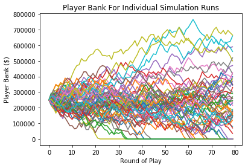

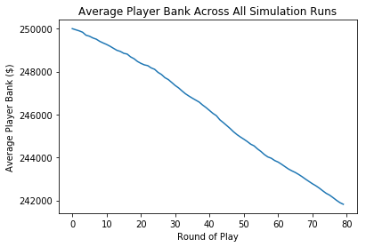

```python
print('Maximum Value Achieved:')
print(max(max_bank_list))
print('Average Maximum Value Achieved:')
print(round(average_max,2))
print('Average Round Where Maximum is Achieved:')
print(round(average_round,2))
print('Average Final Value:')
print(round(average_bank[-1],2))

delta = average_bank[-1] - average_bank[0]
per_hand_loss = delta/(n_hands*n_rounds)
percent_loss = per_hand_loss/bet * 100

print('Average lost or gained per round:')
print(round(per_hand_loss, 2))
print('Percentage of bet lost or gained per round:')
print(round(percent_loss, 2))

#plot a number of individual simulation results
plt.figure(1)
for i in range(0,600000,10000):
    plt.plot(results[i,0:200])

# Add title and axis names
plt.title('Player Bank For Individual Simulation Runs')
plt.xlabel('Round of Play')
plt.ylabel('Player Bank ($)')

#plot average player bank after every hand
plt.figure(2)
plt.plot(average_bank[0:200])

# Add title and axis names
plt.title('Average Player Bank Across All Simulation Runs')
plt.xlabel('Round of Play')
plt.ylabel('Average Player Bank ($)')
```

#### Austin Powers Black Jack Strategy

For fun, we can also look at the Black Jack strategy of another 'International Man of Mystery', Austin Powers. Based on the first movie we learn that Austin Powers, who likes to 'live life dangerously', will hold regardless of the hand being dealt.

https://www.youtube.com/watch?v=HkzMA1jrm00

#### Code Development

The code for Austin Powers' strategy is the same that is used above for Bond, but the logic that determines how the player should behave has been removed so the player will only play the two cards dealt to them.

The dealer's logic in this scenario is unchanged.

Other parameters are adjusted, such as *n_hands*, and *bet* to better match the scenario seen in the movie.

Results are shown below with the full code located in Appendix C.

```
Maximum Value Achieved:
830000
Average Maximum Value Achieved:
542389.82
Average Round Where Maximum is Achieved:
24.36
Average Final Value:
447808.67
Average lost or gained per round:
-652.39
Percentage of bet lost or gained per round:
-6.52
```

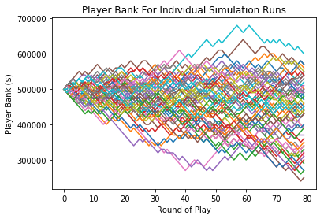

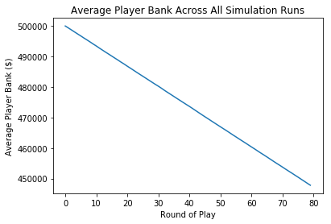

```python
print('Maximum Value Achieved:')
print(max(max_bank_list))
print('Average Maximum Value Achieved:')
print(round(average_max,2))
print('Average Round Where Maximum is Achieved:')
print(round(average_round,2))
print('Average Final Value:')
print(round(average_bank[-1],2))

delta = average_bank[-1] - average_bank[0]
per_hand_loss = delta/(n_hands*n_rounds)
percent_loss = per_hand_loss/bet * 100

print('Average lost or gained per round:')
print(round(per_hand_loss, 2))
print('Percentage of bet lost or gained per round:')
print(round(percent_loss, 2))

#plot a number of individual simulation results
plt.figure(1)
for i in range(0,600000,10000):
    plt.plot(results[i,0:200])

# Add title and axis names
plt.title('Player Bank For Individual Simulation Runs')
plt.xlabel('Round of Play')
plt.ylabel('Player Bank ($)')

#plot average player bank after every hand
plt.figure(2)
plt.plot(average_bank[0:200])

# Add title and axis names
plt.title('Average Player Bank Across All Simulation Runs')
plt.xlabel('Round of Play')
plt.ylabel('Average Player Bank ($)')
```

#### Bond Black Jack Modified For Comparison

To better compare the Bond strategy to Austin Powers, we will run the Bond strategy code again but change the input parameters to match the Austin Powers simulation.

This means a starting bank of \$500,000, \$10,000 bets, and playing one hand at a time.

Running both strategies with the same parameters means that we can easily compare the average final bank value and know that they are starting at the same point and wagering the same amount each round of play.

Results are shown below with the full code located in Appendix D.

```
Maximum Value Achieved:
1000000
Average Maximum Value Achieved:
574280.83
Average Round Where Maximum is Achieved:
36.08
Average Final Value:
496631.15
Average lost or gained per round:
-42.11
Percentage of bet lost or gained per round:
-0.42
```

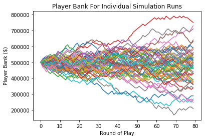

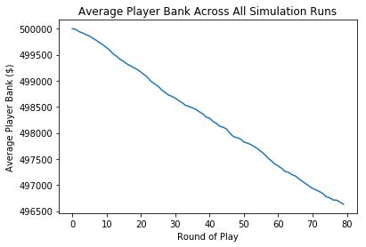

```python
print('Maximum Value Achieved:')
print(max(max_bank_list))
print('Average Maximum Value Achieved:')
print(round(average_max,2))
print('Average Round Where Maximum is Achieved:')
print(round(average_round,2))
print('Average Final Value:')
print(round(average_bank[-1],2))

delta = average_bank[-1] - average_bank[0]
per_hand_loss = delta/(n_hands*n_rounds)
percent_loss = per_hand_loss/bet * 100

print('Average lost or gained per round:')
print(round(per_hand_loss, 2))
print('Percentage of bet lost or gained per round:')
print(round(percent_loss, 2))

#plot a number of individual simulation results
plt.figure(1)
for i in range(0,600000,10000):
    plt.plot(results[i,0:200])

# Add title and axis names
plt.title('Player Bank For Individual Simulation Runs')
plt.xlabel('Round of Play')
plt.ylabel('Player Bank ($)')

#plot average player bank after every hand
plt.figure(2)
plt.plot(average_bank[0:200])

# Add title and axis names
plt.title('Average Player Bank Across All Simulation Runs')
plt.xlabel('Round of Play')
plt.ylabel('Average Player Bank ($)')
```

### Conclusions

When running the simulations, it was initially observed that there was a lot of variation in results for the Black Jack games using the James Bond strategy. This may be due to the fact that Bond strategy will sometimes split hands into two and double bets depending on the hands dealt. So the number of simulations was gradually increased until the final results would repeat between runs. This value was finally set at 600,000 simulation replications and this was used across all games once set.

Looking at the results, the first observation is that in both Roulette and Black Jack the overall trend of the player's bank is steadily decreasing in both games, regardless of strategy.

In Roulette, James Bond's strategy loses on average 7.25% each round. This is the highest loss of any of the games studied.

When playing Black Jack, James Bond's strategy loses only 0.42% each round on average. This means that, after the 80 rounds of play, with one hand played at a time, the average balance of Bond's bank is \$496,631, down from the \$500,000 starting point. Comparing this to Austin Power's strategy we can see that James Bond will perform much better. After the same 80 rounds with the same bet amounts, Austin Powers would have averaged a loss of 6.52% of his bet on every hand. This translates to an average bank of \$447,809 at the end of the 80 rounds of play.

Although the house always wins, there is still potential for Bond to win some money before losing it all. Looking at the graphs of individual simulations we can see that a number of rounds result in at least some wins for the player. James Bond's Black Jack strategy has the potential to double his money, with a maximum of a 100% increase in bank in the 600,000 simulations. The Austin Powers method also has potential to win, but the highest increase over all simulations was only 66%. With the higher risk of losing in Roulette also comes a higher potential reward. Using his Roulette strategy, Bond had a maximum increase in his bank of 103.8% in the the 600,000 simulation runs. The potential to win is there for every strategy, but the real challenge is walking away while still ahead.

So it turns out that even James Bond can't beat the house. All of the strategies that he uses may result in short run wins, but in the end he hasn't found a way to overcome the house advantage.

## Appendix A - Bond Roulette Strategy Code

```python
#import libraries needed for code
import random
import numpy as np
import matplotlib.pyplot as plt

#simulation input parameters
#how many simulation runs to perform
n_sim = 600000
#how many hands/rounds of roulette to perform in each simulation
n_hands = 200
#how much to bet during each round
bet = 200

#initiate variables to store results and number ranges for bets
max_bank_list = []
max_round_list = []
max_loss_list = []
six_list = list(range(13,19))
high_list = list(range(19,37))
rounds = 1

#create a matrix of zeros to store results in
#matrix was filled with zeros so if a player runs out of money
#it will register as 0 for the remaining potential runs
results = np.zeros((n_sim,n_hands))

#for loop to handle simulation replicants
for i in range(0,n_sim):
    #Initialize variables for each new run
    rounds = 1
    loss_count = 1
    max_loss = 1
    max_round = 0
    #starting amount of money the player has
    bank = 10000
    max_bank = 10000
    results[i,0] = bank

    #play rounds of roulette until the player runs out of money
    #or the max number of rounds is achieved
    while rounds < n_hands and bank >= bet*loss_count:
        #select random number for the result of the spin
        result = random.randint(1,37)
        #if statements to determine payout or loss
        if result == 37:
            bank += 0.8*bet*loss_count
            loss_count = 1
        elif result in range(13,19):
            bank += 0.5*bet*loss_count
            loss_count = 1
        elif result in range(19,37):
            bank += 0.4*bet*loss_count
            loss_count = 1
        else:
            bank -= bet*loss_count
            #if player loses, double the bet
            loss_count *= 2

            #cap the bet multiplier based on table limits
            if loss_count > 50:
                loss_count = 50

        #if new max values are achieved store them
        if bank > max_bank:
            max_bank = bank
            max_round = rounds

        if loss_count > max_loss:
            max_loss = loss_count

        #store results of each round
        results[i,rounds] = bank
        #print(round, result, loss_count, bank)
        rounds += 1

    #store the maximum achieved each simulation run
    max_bank_list.append(max_bank)
    max_round_list.append(max_round)
    max_loss_list.append(max_loss)

#average results over all simulation runs
average_bank = np.mean(results,axis=0)
average_max = np.mean(max_bank_list)
average_round = np.mean(max_round_list)
```

## Appendix B - Bond Strategy Black Jack Code

Thank you to Brian Seymour, who's Black Jack simulator I reviewed and used as a starting point to create the code below. His code can be found on Github: https://github.com/engineer-man/youtube/blob/master/031/blackjack_simulator.py#L30

```python
#import libraries needed for code
import random
import numpy as np
import matplotlib.pyplot as plt

#simulation input parameters
#how many simulation runs to perform
n_sim = 600000
#how many hands to play in each round
n_hands = 5
#how many total rounds to play
n_rounds = 80
#how many decks to include in dealing cards
n_decks = 4
#what percentage of cards to use before shuffling the decks
shuffle_perc = 75
#how much to bet every hand
bet = 5000

#function to create shuffled decks
def new_deck():
    std_deck = [
      # 2  3  4  5  6  7  8  9  10  J   Q   K   A
        2, 3, 4, 5, 6, 7, 8, 9, 10, 10, 10, 10, 11,
        2, 3, 4, 5, 6, 7, 8, 9, 10, 10, 10, 10, 11,
        2, 3, 4, 5, 6, 7, 8, 9, 10, 10, 10, 10, 11,
        2, 3, 4, 5, 6, 7, 8, 9, 10, 10, 10, 10, 11,
        ]

    # add more decks
    std_deck = std_deck * n_decks
    # shuffle cards
    random.shuffle(std_deck)
    # return deck for play
    return std_deck[:]

#create a matrix of zeros to store results
results = np.zeros((n_sim,n_rounds))

#initialize variables used after every round
max_bank_list = []
max_round_list = []

#for loop to handle simulation replicants
for i in range(0,n_sim):
    #variables to initialize at start of each run
    rounds = 1
    max_round = 1
    #amount of starting money for each round
    bank = 250000
    max_bank = 250000
    results[i,0] = bank
    #get a new deck of shuffled cards
    deck = new_deck()

    #while loop to continue playinig hands while the player
    #has enough to cover each hand or until the desired number
    #of hands are complete
    while rounds < n_rounds and bank >= (bet * n_hands):
        dealer_cards = []
        player_cards = []
        top_card = []
        bet_value = []

        # deal initial cards to all seats then dealer
        for j in range(0,n_hands):
            top_card.append(deck.pop(0))
            player_cards.append(top_card)
            top_card = []
            bet_value.append(1)
        dealer_cards.append(deck.pop(0))
        # deal second card to all seats then dealer
        for j in range(0,n_hands):
            top_card.append(deck.pop(0))
            player_cards[j].extend(top_card)
            top_card = []
        dealer_cards.append(deck.pop(0))


        # handle logic of how to play each hand for player
        for r in range(0,n_hands):
            deal = True

            while deal == True:

                #if a hand has only one card due to splitting
                #deal a second card first
                if len(player_cards[r]) == 1:
                    top_card.append(deck.pop(0))
                    player_cards[r].extend(top_card)
                    top_card = []

                #look at sum of cards in current hand
                player_sum = sum(player_cards[r])
                #if the hand contains an Ace use the following logic for the
                #initial decision
                if 11 in player_cards[r] and len(player_cards[r]) == 2:
                    if 10 in player_cards[r]:
                        deal = False
                    elif 9 in player_cards[r]:
                        deal = False
                    elif 8 in player_cards[r]:
                        deal = False
                        if dealer_cards[0] == 6:
                            bet_value[r] = 2
                    elif 7 in player_cards[r]:
                        deal = False
                        if dealer_cards[0] in [3,4,5,6]:
                            bet_value[r] = 2
                        elif dealer_cards[0] in [9,10]:
                            deal = True
                    elif 6 in player_cards[r]:
                        deal = False
                        if dealer_cards[0] in [2,3,4,5,6]:
                            bet_value[r] = 2
                        if dealer_cards[0] in [7,8,9,10,11]:
                            deal = True
                    else:
                        deal = True
                        if dealer_cards[0] in [4,5,6]:
                            bet_value[r] = 2
                #if the hand contains two cards of the same value use the
                #following logic for the initial decision
                elif player_cards[r][0] == player_cards[r][1] and len(player_cards[r]) == 2:
                    if player_cards[r][0] in [8,11]:
                        split_card = player_cards[r][0]
                        del player_cards[r][1]
                        player_cards.insert(r+1,[split_card])
                        bet_value.insert(r+1,1)
                        deal = True
                    elif player_cards[r][0] == 10:
                        deal = False
                    elif player_cards[r][0] == 9:
                        if dealer_cards[0] in [2,3,4,5,6,8,9]:
                            split_card = player_cards[r][0]
                            del player_cards[r][1]
                            player_cards.insert(r+1,[split_card])
                            bet_value.insert(r+1,1)
                            deal = True
                        else:
                            deal = False
                    elif player_cards[r][0] == 7:
                        if dealer_cards[0] in [2,3,4,5,6,7]:
                            split_card = player_cards[r][0]
                            del player_cards[r][1]
                            player_cards.insert(r+1,[split_card])
                            bet_value.insert(r+1,1)
                            deal = True
                        elif dealer_cards[0] in [8,9,11]:
                            deal = True
                        else:
                            deal = False
                    elif player_cards[r][0] == 6:
                        if dealer_cards[0] in [2,3,4,5,6]:
                            split_card = player_cards[r][0]
                            del player_cards[r][1]
                            player_cards.insert(r+1,[split_card])
                            bet_value.insert(r+1,1)
                            deal = True
                        else:
                            deal = True
                    elif player_cards[r][0] == 5:
                        if dealer_cards[0] in [2,3,4,5,6,7,8,9]:
                            bet_value[r] = 2
                            deal = True
                        else:
                            deal = True
                    elif player_cards[r][0] == 4:
                        if dealer_cards[0] in [5,6]:
                            bet_value[r] = 2
                            deal = True
                        else:
                            deal = True
                    elif player_cards[r][0] == 3:
                        if dealer_cards[0] in [4,5,6,7]:
                            split_card = player_cards[r][0]
                            del player_cards[r][1]
                            player_cards.insert(r+1,[split_card])
                            bet_value.insert(r+1,1)
                            deal = True
                        else:
                            deal = True
                    elif player_cards[r][0] == 2:
                        if dealer_cards[0] in [3,4,5,6,7]:
                            split_card = player_cards[r][0]
                            del player_cards[r][1]
                            player_cards.insert(r+1,[split_card])
                            bet_value.insert(r+1,1)
                            deal = True
                        else:
                            deal = True
                #if there is no ace and two different cards were dealt
                #follow this logic based on the current sum of the hand
                else:
                    #print('sum track')
                    if player_sum >= 17:
                        deal = False
                    elif player_sum in [13,14,15,16] and dealer_cards[0] in [7,8,9,10,11]:
                        deal = True
                    elif player_sum == 12 and dealer_cards[0] in [2,3,7,8,9,10,11]:
                        deal = True
                    elif player_sum == 11:
                        deal = True
                        bet_value[r] = 2
                    elif player_sum == 10:
                        deal = True
                        if dealer_cards[0] not in [10,11]:
                            bet_value[r] = 2
                    elif player_sum == 9:
                        deal = True
                        if dealer_cards[0] not in [7,8,9,10,11]:
                            bet_value[r] = 2
                    elif player_sum == 8:
                        deal = True
                        if dealer_cards[0] not in [2,3,4,7,8,9,10,11]:
                            bet_value[r] = 2
                    elif player_sum in [5,6,7]:
                        deal = True
                    else:
                        deal = False
                #if a new card is needed based on logic, deal one
                if deal == True:
                    player_cards[r].append(deck.pop(0))
                #if the hand contains an Ace assign 1 or 11 depending on hand
                if sum(player_cards[r]) > 21:
                    for b, card in enumerate(player_cards[r]):
                        if card == 11:
                            player_cards[r][b] = 1


        #handle logic of how to play dealer hand
        while sum(dealer_cards) < 18:
            exit = False
            # check for soft 17
            if sum(dealer_cards) == 17:
                exit = True
                # check for an ace and convert to 1 if found
                for a, card in enumerate(dealer_cards):
                    if card == 11:
                        exit = False
                        dealer_cards[a] = 1

            # deal new card
            dealer_cards.append(deck.pop(0))
            #print('new hand',dealer_cards)

            # assign 1 or 11 depending on hand
            if sum(dealer_cards) > 21:
                for b, card in enumerate(dealer_cards):
                    if card == 11:
                        exit = False
                        dealer_cards[b] = 1

            if exit:
                break

        #calculate final dealer sum
        dealer_sum = sum(dealer_cards)

        #determine if each hand wins or loses
        #be sure to loop over all hands if any cards were split
        for r in range(0,len(bet_value)):
            player_sum = sum(player_cards[r])
            #dealer busts
            if dealer_sum > 21 and player_sum <= 21:
                bank += bet*bet_value[r]
            #player has higher sum with no busts
            elif player_sum <= 21 and player_sum > dealer_sum:
                bank += bet*bet_value[r]
            #dealer has higher sum with no busts
            elif dealer_sum <= 21 and dealer_sum > player_sum:
                bank -= bet*bet_value[r]
            #player busts
            elif player_sum > 21:
                bank -= bet*bet_value[r]
            #draw - player and dealer equal
            else:
                bank = bank

        #update max values if new max achieved
        if bank > max_bank:
            max_bank = bank
            max_round = rounds

        #store results after each round of play
        results[i,rounds] = bank

        rounds += 1

        # reshuffle cards at shuffle_perc percentage
        if (float(len(deck)) / (52 * n_decks)) * 100 < shuffle_perc:
            deck = new_deck()


    #store max for each replicant of simulation
    max_bank_list.append(max_bank)
    max_round_list.append(max_round)
    max_loss_list.append(max_loss)

#look at average values over all replicants
average_bank = np.mean(results,axis=0)
average_max = np.mean(max_bank_list)
average_round = np.mean(max_round_list)
```

## Appendix C - Austin Powers Strategy Black Jack Code

```python
#import libraries needed for code
import random
import numpy as np
import matplotlib.pyplot as plt

#simulation input parameters
#how many simulation runs to perform
n_sim = 600000
#how many hands to play in each round
n_hands = 1
#how many total rounds to play
n_rounds = 80
#how many decks to include in dealing cards
n_decks = 4
#what percentage of cards to use before shuffling the decks
shuffle_perc = 75
#how much to bet every hand
bet = 10000

#function to create shuffled decks
def new_deck():
    std_deck = [
      # 2  3  4  5  6  7  8  9  10  J   Q   K   A
        2, 3, 4, 5, 6, 7, 8, 9, 10, 10, 10, 10, 11,
        2, 3, 4, 5, 6, 7, 8, 9, 10, 10, 10, 10, 11,
        2, 3, 4, 5, 6, 7, 8, 9, 10, 10, 10, 10, 11,
        2, 3, 4, 5, 6, 7, 8, 9, 10, 10, 10, 10, 11,
        ]

    # add more decks
    std_deck = std_deck * n_decks
    # shuffle cards
    random.shuffle(std_deck)
    # return deck for play
    return std_deck[:]

#create a matrix of zeros to store results
results = np.zeros((n_sim,n_rounds))

#initialize variables used after every round
max_bank_list = []
max_round_list = []

#for loop to handle simulation replicants
for i in range(0,n_sim):
    #variables to initialize at start of each run
    rounds = 1
    max_round = 1
    #amount of starting money for each round
    bank = 500000
    max_bank = 500000
    results[i,0] = bank
    #get a new deck of shuffled cards
    deck = new_deck()

    #while loop to continue playinig hands while the player
    #has enough to cover each hand or until the desired number
    #of hands are complete
    while rounds < n_rounds and bank >= (bet * n_hands):
        dealer_cards = []
        player_cards = []
        top_card = []
        bet_value = []

        # deal initial cards to all seats then dealer
        for j in range(0,n_hands):
            top_card.append(deck.pop(0))
            player_cards.append(top_card)
            top_card = []
            bet_value.append(1)
        dealer_cards.append(deck.pop(0))
        # deal second card to all seats then dealer
        for j in range(0,n_hands):
            top_card.append(deck.pop(0))
            player_cards[j].extend(top_card)
            top_card = []
        dealer_cards.append(deck.pop(0))


        # handle logic of how to play each hand for player
        # in this variation we only play the two cards dealt

        #handle logic of how to play dealer hand
        while sum(dealer_cards) < 18:
            exit = False
            # check for soft 17
            if sum(dealer_cards) == 17:
                exit = True
                # check for an ace and convert to 1 if found
                for a, card in enumerate(dealer_cards):
                    if card == 11:
                        exit = False
                        dealer_cards[a] = 1

            # deal new card
            dealer_cards.append(deck.pop(0))
            #print('new hand',dealer_cards)

            # assign 1 or 11 depending on hand
            if sum(dealer_cards) > 21:
                for b, card in enumerate(dealer_cards):
                    if card == 11:
                        exit = False
                        dealer_cards[b] = 1

            if exit:
                break

        #calculate final dealer sum
        dealer_sum = sum(dealer_cards)

        #determine if each hand wins or loses
        #be sure to loop over all hands if any cards were split
        for r in range(0,len(bet_value)):
            player_sum = sum(player_cards[r])
            #dealer busts
            if dealer_sum > 21 and player_sum <= 21:
                bank += bet*bet_value[r]
            #player has higher sum with no busts
            elif player_sum <= 21 and player_sum > dealer_sum:
                bank += bet*bet_value[r]
            #dealer has higher sum with no busts
            elif dealer_sum <= 21 and dealer_sum > player_sum:
                bank -= bet*bet_value[r]
            #player busts
            elif player_sum > 21:
                bank -= bet*bet_value[r]
            #draw - player and dealer equal
            else:
                bank = bank

        #update max values if new max achieved
        if bank > max_bank:
            max_bank = bank
            max_round = rounds

        #store results after each round of play
        results[i,rounds] = bank

        rounds += 1

        # reshuffle cards at shuffle_perc percentage
        if (float(len(deck)) / (52 * n_decks)) * 100 < shuffle_perc:
            deck = new_deck()


    #store max for each replicant of simulation
    max_bank_list.append(max_bank)
    max_round_list.append(max_round)
    max_loss_list.append(max_loss)

#look at average values over all replicants
average_bank = np.mean(results,axis=0)
average_max = np.mean(max_bank_list)
average_round = np.mean(max_round_list)
```

## Appendix D - Bond Black Jack Comparison Code

```python
import random
import numpy as np
import matplotlib.pyplot as plt

# configuration options
n_sim = 600000
n_hands = 1
n_rounds = 80
n_decks = 4
shuffle_perc = 75
bet = 10000

#import libraries needed for code
import random
import numpy as np
import matplotlib.pyplot as plt

#simulation input parameters
#how many simulation runs to perform
n_sim = 600000
#how many hands to play in each round
n_hands = 1
#how many total rounds to play
n_rounds = 80
#how many decks to include in dealing cards
n_decks = 4
#what percentage of cards to use before shuffling the decks
shuffle_perc = 75
#how much to bet every hand
bet = 10000

#function to create shuffled decks
def new_deck():
    std_deck = [
      # 2  3  4  5  6  7  8  9  10  J   Q   K   A
        2, 3, 4, 5, 6, 7, 8, 9, 10, 10, 10, 10, 11,
        2, 3, 4, 5, 6, 7, 8, 9, 10, 10, 10, 10, 11,
        2, 3, 4, 5, 6, 7, 8, 9, 10, 10, 10, 10, 11,
        2, 3, 4, 5, 6, 7, 8, 9, 10, 10, 10, 10, 11,
        ]

    # add more decks
    std_deck = std_deck * n_decks
    # shuffle cards
    random.shuffle(std_deck)
    # return deck for play
    return std_deck[:]

#create a matrix of zeros to store results
results = np.zeros((n_sim,n_rounds))

#initialize variables used after every round
max_bank_list = []
max_round_list = []

#for loop to handle simulation replicants
for i in range(0,n_sim):
    #variables to initialize at start of each run
    rounds = 1
    max_round = 1
    #amount of starting money for each round
    bank = 500000
    max_bank = 500000
    results[i,0] = bank
    #get a new deck of shuffled cards
    deck = new_deck()

    #while loop to continue playinig hands while the player
    #has enough to cover each hand or until the desired number
    #of hands are complete
    while rounds < n_rounds and bank >= (bet * n_hands):
        dealer_cards = []
        player_cards = []
        top_card = []
        bet_value = []

        # deal initial cards to all seats then dealer
        for j in range(0,n_hands):
            top_card.append(deck.pop(0))
            player_cards.append(top_card)
            top_card = []
            bet_value.append(1)
        dealer_cards.append(deck.pop(0))
        # deal second card to all seats then dealer
        for j in range(0,n_hands):
            top_card.append(deck.pop(0))
            player_cards[j].extend(top_card)
            top_card = []
        dealer_cards.append(deck.pop(0))


        # handle logic of how to play each hand for player
        for r in range(0,n_hands):
            deal = True

            while deal == True:

                #if a hand has only one card due to splitting
                #deal a second card first
                if len(player_cards[r]) == 1:
                    top_card.append(deck.pop(0))
                    player_cards[r].extend(top_card)
                    top_card = []

                #look at sum of cards in current hand
                player_sum = sum(player_cards[r])
                #if the hand contains an Ace use the following logic for the
                #initial decision
                if 11 in player_cards[r] and len(player_cards[r]) == 2:
                    if 10 in player_cards[r]:
                        deal = False
                    elif 9 in player_cards[r]:
                        deal = False
                    elif 8 in player_cards[r]:
                        deal = False
                        if dealer_cards[0] == 6:
                            bet_value[r] = 2
                    elif 7 in player_cards[r]:
                        deal = False
                        if dealer_cards[0] in [3,4,5,6]:
                            bet_value[r] = 2
                        elif dealer_cards[0] in [9,10]:
                            deal = True
                    elif 6 in player_cards[r]:
                        deal = False
                        if dealer_cards[0] in [2,3,4,5,6]:
                            bet_value[r] = 2
                        if dealer_cards[0] in [7,8,9,10,11]:
                            deal = True
                    else:
                        deal = True
                        if dealer_cards[0] in [4,5,6]:
                            bet_value[r] = 2
                #if the hand contains two cards of the same value use the
                #following logic for the initial decision
                elif player_cards[r][0] == player_cards[r][1] and len(player_cards[r]) == 2:
                    if player_cards[r][0] in [8,11]:
                        split_card = player_cards[r][0]
                        del player_cards[r][1]
                        player_cards.insert(r+1,[split_card])
                        bet_value.insert(r+1,1)
                        deal = True
                    elif player_cards[r][0] == 10:
                        deal = False
                    elif player_cards[r][0] == 9:
                        if dealer_cards[0] in [2,3,4,5,6,8,9]:
                            split_card = player_cards[r][0]
                            del player_cards[r][1]
                            player_cards.insert(r+1,[split_card])
                            bet_value.insert(r+1,1)
                            deal = True
                        else:
                            deal = False
                    elif player_cards[r][0] == 7:
                        if dealer_cards[0] in [2,3,4,5,6,7]:
                            split_card = player_cards[r][0]
                            del player_cards[r][1]
                            player_cards.insert(r+1,[split_card])
                            bet_value.insert(r+1,1)
                            deal = True
                        elif dealer_cards[0] in [8,9,11]:
                            deal = True
                        else:
                            deal = False
                    elif player_cards[r][0] == 6:
                        if dealer_cards[0] in [2,3,4,5,6]:
                            split_card = player_cards[r][0]
                            del player_cards[r][1]
                            player_cards.insert(r+1,[split_card])
                            bet_value.insert(r+1,1)
                            deal = True
                        else:
                            deal = True
                    elif player_cards[r][0] == 5:
                        if dealer_cards[0] in [2,3,4,5,6,7,8,9]:
                            bet_value[r] = 2
                            deal = True
                        else:
                            deal = True
                    elif player_cards[r][0] == 4:
                        if dealer_cards[0] in [5,6]:
                            bet_value[r] = 2
                            deal = True
                        else:
                            deal = True
                    elif player_cards[r][0] == 3:
                        if dealer_cards[0] in [4,5,6,7]:
                            split_card = player_cards[r][0]
                            del player_cards[r][1]
                            player_cards.insert(r+1,[split_card])
                            bet_value.insert(r+1,1)
                            deal = True
                        else:
                            deal = True
                    elif player_cards[r][0] == 2:
                        if dealer_cards[0] in [3,4,5,6,7]:
                            split_card = player_cards[r][0]
                            del player_cards[r][1]
                            player_cards.insert(r+1,[split_card])
                            bet_value.insert(r+1,1)
                            deal = True
                        else:
                            deal = True
                #if there is no ace and two different cards were dealt
                #follow this logic based on the current sum of the hand
                else:
                    #print('sum track')
                    if player_sum >= 17:
                        deal = False
                    elif player_sum in [13,14,15,16] and dealer_cards[0] in [7,8,9,10,11]:
                        deal = True
                    elif player_sum == 12 and dealer_cards[0] in [2,3,7,8,9,10,11]:
                        deal = True
                    elif player_sum == 11:
                        deal = True
                        bet_value[r] = 2
                    elif player_sum == 10:
                        deal = True
                        if dealer_cards[0] not in [10,11]:
                            bet_value[r] = 2
                    elif player_sum == 9:
                        deal = True
                        if dealer_cards[0] not in [7,8,9,10,11]:
                            bet_value[r] = 2
                    elif player_sum == 8:
                        deal = True
                        if dealer_cards[0] not in [2,3,4,7,8,9,10,11]:
                            bet_value[r] = 2
                    elif player_sum in [5,6,7]:
                        deal = True
                    else:
                        deal = False
                #if a new card is needed based on logic, deal one
                if deal == True:
                    player_cards[r].append(deck.pop(0))
                #if the hand contains an Ace assign 1 or 11 depending on hand
                if sum(player_cards[r]) > 21:
                    for b, card in enumerate(player_cards[r]):
                        if card == 11:
                            player_cards[r][b] = 1


        #handle logic of how to play dealer hand
        while sum(dealer_cards) < 18:
            exit = False
            # check for soft 17
            if sum(dealer_cards) == 17:
                exit = True
                # check for an ace and convert to 1 if found
                for a, card in enumerate(dealer_cards):
                    if card == 11:
                        exit = False
                        dealer_cards[a] = 1

            # deal new card
            dealer_cards.append(deck.pop(0))
            #print('new hand',dealer_cards)

            # assign 1 or 11 depending on hand
            if sum(dealer_cards) > 21:
                for b, card in enumerate(dealer_cards):
                    if card == 11:
                        exit = False
                        dealer_cards[b] = 1

            if exit:
                break

        #calculate final dealer sum
        dealer_sum = sum(dealer_cards)

        #determine if each hand wins or loses
        #be sure to loop over all hands if any cards were split
        for r in range(0,len(bet_value)):
            player_sum = sum(player_cards[r])
            #dealer busts
            if dealer_sum > 21 and player_sum <= 21:
                bank += bet*bet_value[r]
            #player has higher sum with no busts
            elif player_sum <= 21 and player_sum > dealer_sum:
                bank += bet*bet_value[r]
            #dealer has higher sum with no busts
            elif dealer_sum <= 21 and dealer_sum > player_sum:
                bank -= bet*bet_value[r]
            #player busts
            elif player_sum > 21:
                bank -= bet*bet_value[r]
            #draw - player and dealer equal
            else:
                bank = bank

        #update max values if new max achieved
        if bank > max_bank:
            max_bank = bank
            max_round = rounds

        #store results after each round of play
        results[i,rounds] = bank

        rounds += 1

        # reshuffle cards at shuffle_perc percentage
        if (float(len(deck)) / (52 * n_decks)) * 100 < shuffle_perc:
            deck = new_deck()


    #store max for each replicant of simulation
    max_bank_list.append(max_bank)
    max_round_list.append(max_round)
    max_loss_list.append(max_loss)

#look at average values over all replicants
average_bank = np.mean(results,axis=0)
average_max = np.mean(max_bank_list)
average_round = np.mean(max_round_list)
```

Fin.